# Clase 6: Integrar tablas y comunicar en R Markdown

Logo de R

Índice general del curso

Vas a unir tablas y preparar un informe que se pueda generar de nuevo con el mismo código.

Ejemplo comentado y lecturas adicionales · Referencias

## Agenda

| Minutos | Actividad |
| --- | --- |
| 00–40 | Bloque 1. Unir ventas con un catálogo |
| 40–80 | Bloque 2. Elegir evidencia para una pregunta |
| 80–90 | Pausa |
| 90–135 | Bloque 3. Generar un informe con R Markdown |
| 135–150 | Repaso de los resultados de las prácticas y consultas |

En cada bloque, primero revisamos la teoría, luego ejecutamos el ejemplo y al final practicamos en parejas o tríos. En cada práctica, alternen quién escribe el código y quién revisa el resultado.

## 1. Unir ventas con un catálogo

### Teoría

Una unión añade información de una tabla a otra mediante una columna en común, llamada clave. Con `left_join()`, cada venta conserva su fila y recibe la información de su sede en el catálogo. Cuando no encuentra coincidencia, las columnas del catálogo quedan como `NA`.

Antes de unir, verificá que el catálogo tenga una fila por sede. Si una sede aparece dos veces, una venta puede terminar repetida y alterar los totales. Usá `anti_join()` para encontrar sedes sin coincidencia y compará el número de filas antes y después de la unión.

[Unir tablas por una clave](https://r4ds.hadley.nz/joins.html) · *Learning R* (Cotton, 2013, cap. 5).

### Ejemplo

Comprobá si hay ventas cuya sede falta en el catálogo. Después compará cuántas filas tenés antes y después de la unión.

```r
source("herramientas/preparar_datos.R")
ventas <- preparar_ventas()
sedes <- read_csv("datos/sedes.csv", show_col_types = FALSE)
stopifnot(!anyDuplicated(sedes$sede))
anti_join(ventas, sedes, by = "sede")
```

```
## # A tibble: 0 x 7
## # i 7 variables: id_venta <int>, fecha <date>, sede <chr>, producto <chr>,
## #   unidades <dbl>, precio_crc <dbl>, ingreso_crc <dbl>
```

```r
integradas <- left_join(ventas, sedes, by = "sede", relationship = "many-to-one")
stopifnot(nrow(integradas) == nrow(ventas), !anyNA(integradas$region))
```

### Práctica en grupo

1. Revisen si `sedes$sede` tiene duplicados con `anyDuplicated()`.
2. Ejecuten `anti_join(ventas, sedes, by = "sede")` e interpreten cuántas ventas quedaron sin sede en el catálogo.
3. Ejecuten `left_join()` como en el ejemplo y comparen las cantidades de filas antes y después.
4. Expliquen qué podría pasar con esas cantidades si Heredia figurara dos veces en el catálogo.

## 2. Elegir evidencia para una pregunta

### Teoría

La tabla ayuda a consultar los valores exactos y el gráfico ayuda a comparar patrones. Elegí la misma unidad de análisis para ambos. Si la tabla tiene una fila por sede y producto, el gráfico debe mostrar esa combinación o explicar cómo la agrupó.

Cuando contés lo que encontraste, nombrá el grupo y da la cifra con su unidad. Si quedaron ventas fuera del cálculo, explicá por qué y cómo podría afectar la comparación.

[Visualizar datos](https://r4ds.hadley.nz/data-visualize.html) · *Learning R* (Cotton, 2013, cap. 14).

### Ejemplo

Buscá en la tabla el ingreso de un producto en una sede y localizá esa misma cifra en el gráfico.

```r
source("herramientas/preparar_datos.R")
library(ggplot2)
ventas <- preparar_ventas()
evidencia <- ventas |> group_by(sede, producto) |>
  summarise(transacciones = n(), faltantes = sum(is.na(unidades)),
            ingreso_observado = sum(ingreso_crc, na.rm = TRUE), .groups = "drop")
knitr::kable(evidencia, caption = "Ingreso observado por sede y producto (CRC)")
```

Ingreso observado por sede y producto (CRC)

| sede | producto | transacciones | faltantes | ingreso_observado |
| --- | --- | --- | --- | --- |
| Cartago | Café | 13 | 0 | 63000 |
| Cartago | Pan | 13 | 1 | 32400 |
| Cartago | Té | 14 | 1 | 44400 |
| Heredia | Café | 15 | 1 | 55500 |
| Heredia | Pan | 13 | 1 | 32400 |
| Heredia | Té | 13 | 1 | 43200 |
| San José | Café | 13 | 0 | 61500 |
| San José | Pan | 13 | 1 | 27900 |
| San José | Té | 13 | 1 | 49200 |

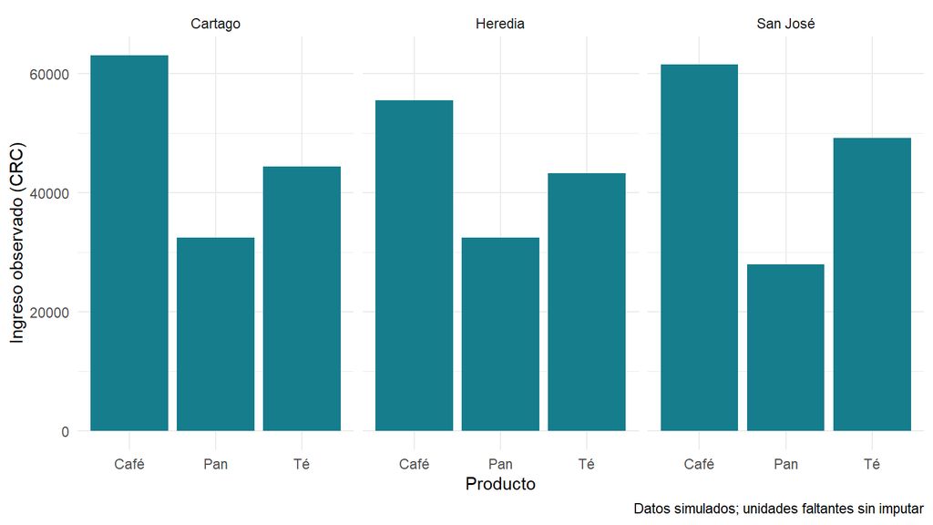

```r
ggplot(evidencia, aes(producto, ingreso_observado)) +
  geom_col(fill = "#167d8d") + facet_wrap(~ sede) +
  labs(x = "Producto", y = "Ingreso observado (CRC)",
       caption = "Datos simulados; unidades faltantes sin imputar") + theme_minimal()
```

### Práctica en grupo

1. Elijan un producto y una sede del resumen. Localicen ese monto en la tabla y en el gráfico.
2. Dentro de esa sede, identifiquen el producto con la barra más alta y anoten su monto exacto de la tabla.
3. Consulten la columna de faltantes para esa combinación y expliquen qué ingresos quedaron excluidos.
4. Escriban un hallazgo con cifra y unidad, y agreguen una limitación que se desprenda del conteo de faltantes.

## 3. Generar un informe con R Markdown

### Teoría

Un archivo `.Rmd` guarda el texto junto con el código que genera resultados. Los bloques de R contienen instrucciones. Las explicaciones se escriben fuera de esos bloques. Al pulsar **Knit**, el informe ejecuta su código en orden, por lo que cada objeto debe crearse antes de usarse.

Si tu código necesita un CSV, guardá el `.Rmd` en la carpeta indicada y usá rutas relativas. Después de generar el HTML, revisá que la tabla, el gráfico y las cifras que escribiste correspondan a la misma ejecución.

[guía de R Markdown de Posit · Texto, bloques de código y generación del informe](https://rmarkdown.rstudio.com/articles_intro.html)

### Ejemplo

1. En RStudio, elegí **File → New File → R Markdown**, seleccioná **HTML** y guardá el archivo como `ensayo_informe.Rmd` en la carpeta principal del proyecto.
2. Conservá el encabezado inicial entre las dos líneas de tres guiones. Borrá el contenido que viene después.
3. En el espacio en blanco, escribí `## Total observado` y dejá una línea en blanco. Insertá un bloque con **Insert → R** en el editor. Pegá la línea de abajo dentro del bloque.
4. Guardá y pulsá **Knit**. En el HTML buscá el título, el código y el resultado.

```r
sum(c(1500, 2500, NA), na.rm = TRUE)
```

```
## [1] 4000
```

### Práctica en grupo

1. Creen el informe de ensayo y generen un primer HTML con **Knit**. Localicen en el HTML el total calculado.
2. Escriban fuera del código una oración con el total y el número de montos conocidos.
3. Cambien 2500 por 3500 y actualicen la oración para que corresponda al nuevo cálculo.
4. Generen el HTML otra vez y pídanle a otra persona que compare la oración y el resultado mostrado.

## Evaluación fuera de clase

Proyecto final. Hacé esta evaluación de forma individual fuera de clase.